# KI Bioinformatics H7F5633 - Assignment 1

David Hu

2026-11-03

## Task 3 - R Installation

All required software was installed prior to the course.

- R version 4.4.3 (2025-02-28)
- BiocManager version 1.30.27
- Tidyverse version 2.0.0
- ggplot2 version 4.0.3

## Task 4 - Basic R Operations

### 1. Square root of 10

```r
sqrt(10)
```

```
## [1] 3.162278
```

The square root of 10 is 3.162.

### 2. Logarithm of 32 to base 2

```r
log(32, base = 2)
```

```
## [1] 5
```

This returns 5, because 2^5 = 32.

### 3. Sum of numbers 1 to 1000

```r
sum(seq(1, 1000))
```

```
## [1] 500500
```

The sum of all integers from 1 to 1000 is 500,500.

### 4. Sum of even numbers from 2 to 1000

```r
sum(seq(2, 1000, 2))
```

```
## [1] 250500
```

By specifying a step of 2 starting from 2, seq() generates only even numbers. The sum is 250,500.

### 5. Pairwise comparisons for 100 genes

```r
choose(100, 2)
```

```
## [1] 4950
```

Order does not matter for a pairwise comparison — gene A vs gene B is the same as gene B vs gene A — so we use combinations. There are 4,950 possible pairwise comparisons for 100 genes.

### 6. Ways to arrange 100 genes in triples

```r
factorial(100) / factorial(100 - 3)
```

```
## [1] 970200
```

Unlike pairwise comparisons, arrangements imply order matters — gene A→B→C is distinct from gene C→B→A. This uses the permutations formula n!/(n-k)!. There are 970,200 ways to arrange 100 genes in triples.

## Task 5 - Using R Example Datasets

### 1-2. Loading and describing the CO2 dataset

```r
data("CO2")
head(CO2)
```

```
##   Plant   Type  Treatment conc uptake
## 1   Qn1 Quebec nonchilled   95   16.0
## 2   Qn1 Quebec nonchilled  175   30.4
## 3   Qn1 Quebec nonchilled  250   34.8
## 4   Qn1 Quebec nonchilled  350   37.2
## 5   Qn1 Quebec nonchilled  500   35.3
## 6   Qn1 Quebec nonchilled  675   39.2
```

Data talks about CO2 uptake in grass plants. It has 84 rows and 5 columns of data and is from an experiment on the cold tolerance of a grass species.

### 3. Average and median CO2 uptake by region

```r
quebec <- CO2[CO2$Type == "Quebec", ]
mississippi <- CO2[CO2$Type == "Mississippi", ]

mean(quebec$uptake)
```

```
## [1] 33.54286
```

```r
median(quebec$uptake)
```

```
## [1] 37.15
```

```r
mean(mississippi$uptake)
```

```
## [1] 20.88333
```

```r
median(mississippi$uptake)
```

```
## [1] 19.3
```

Quebec plants had a mean uptake of 33.54 and median of 37.15 umol/m^2/sec. Mississippi plants had a mean uptake of 20.88 and median of 19.30 umol/m^2/sec.

## Task 6 - R Functions

### 1

```r
mean_median_ratio <- function(x) {
  result <- mean(x) / median(x)
  return(result)
}
```

Divides the mean by the median

### 2

```r
ignore_top_bottom_mean <- function(x) {
  x_trimmed <- x[x != min(x) & x != max(x)]
  result <- mean(x_trimmed)
  return(result)
}
```

Removes the max and min and gives the mean of the rest of the values

### 3-4

Pipes (%>%) pass the output of one function directly into the next. Use them for sequential data transformations. Avoid pipes when there are multiple inputs/outputs per step, or when steps are not linear

Apply functions (apply, lapply, sapply) replace loops by applying a function across rows, columns, or list elements simultaneously. They make code more concise and readable. Useful when running the same operation across multiple genes, samples, or datasets, which is common in genomics workflows.

## Task 7 - Basic Visualization with R

### 7.1a - Height distribution histograms

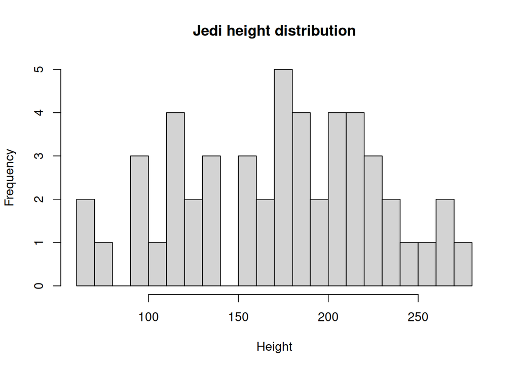

```r
library(remotes)
library(ggplot2)
magic_guys <- read.csv("magic_guys.csv")

# Base R histogram
jedi <- magic_guys[magic_guys$species == "jedi", ]
sith <- magic_guys[magic_guys$species == "sith", ]

hist(jedi$length, breaks=20,
     main="Jedi height distribution",
     xlab="Height")
```

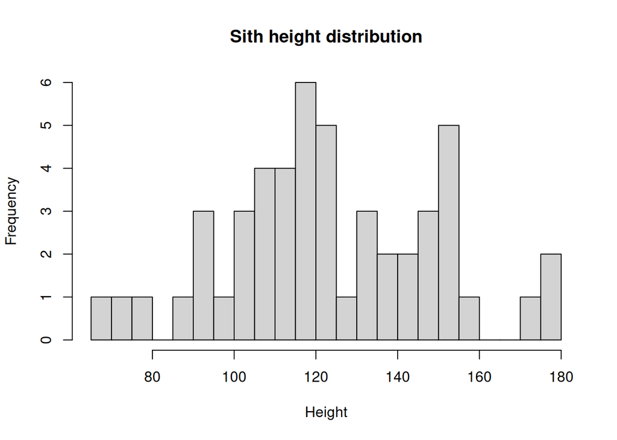

```r
hist(sith$length, breaks=20,
     main="Sith height distribution",
     xlab="Height")
```

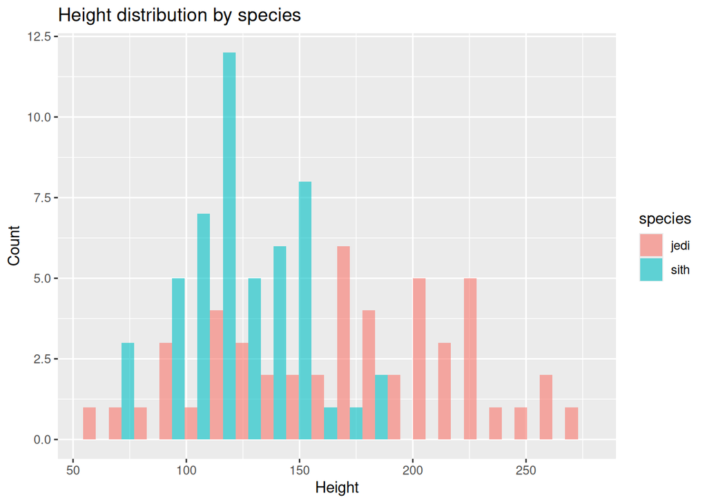

```r
# ggplot histogram
ggplot(magic_guys, aes(x=length, fill=species)) +
  geom_histogram(bins=20, alpha=0.6, position="dodge") +
  labs(title="Height distribution by species",
       x="Height",
       y="Count")
```

### 7.1b - Boxplots

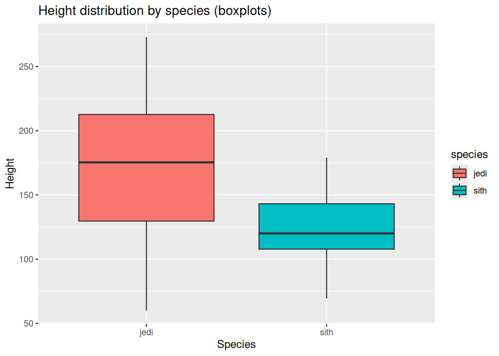

```r
ggplot(magic_guys, aes(x=species, y=length, fill=species))+
    geom_boxplot() +
  labs(title="Height distribution by species (boxplots)", x="Species", y="Height")
```

### 7.1c - Saving plots

```r
# PNG - for web/presentations, small file size
png("height_boxplot.png")
ggplot(magic_guys, aes(x=species, y=length, fill=species))+
  geom_boxplot() +
  labs(title="Height distribution by species (boxplots)", x="Species", y="Height")
dev.off()
```

```r
# PDF - for publications, infinitely scalable
pdf("height_boxplot.pdf")
ggplot(magic_guys, aes(x=species, y=length, fill=species))+
  geom_boxplot() +
  labs(title="Height distribution by species (boxplots)", x="Species", y="Height")
dev.off()
```

```r
# SVG - for editing in Illustrator/Inkscape
svg("height_boxplot.svg")
ggplot(magic_guys, aes(x=species, y=length, fill=species))+
  geom_boxplot() +
  labs(title="Height distribution by species (boxplots)", x="Species", y="Height")
dev.off()
```

PNG is appropriate for digital use where file size matters. PDF is the standard for academic publications as it is vector-based and scales without pixelation. SVG is useful when the figure needs further editing in vector graphics software such as Inkscape or Adobe Illustrator.

### 7.2a - Microarray matrix dimensions

```r
microarray <- read.table("microarray_data.tab", header=TRUE, sep="\t")
dim(microarray)
```

```
## [1]  553 1000
```

```r
head(microarray[, 1:5])
```

```
##       g1 g2     g3    g4     g5
## 1  1.802 NA -0.182 1.312  3.497
## 2     NA NA  7.693    NA  0.193
## 3  1.079 NA  1.556 1.652     NA
## 4  3.607 NA  1.914    NA  1.400
## 5 -1.700 NA  0.943    NA -0.170
## 6     NA NA  0.043    NA  0.729
```

### 7.2b - Missing values per gene

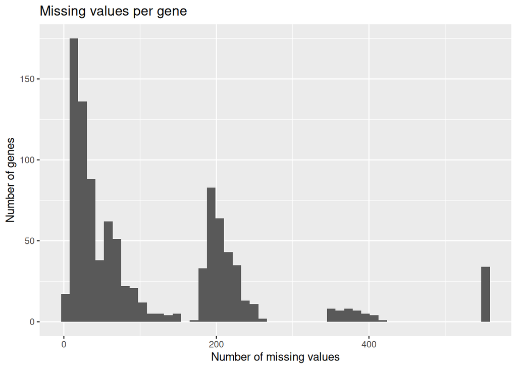

```r
na_counts <- colSums(is.na(microarray))

ggplot(data.frame(gene=names(na_counts), na_count=na_counts),
       aes(x=na_count)) +
  geom_histogram(bins=50) +
  labs(title="Missing values per gene",
       x="Number of missing values",
       y="Number of genes")
```

### 7.2c - Genes exceeding missingness thresholds

```r
genes_10 <- names(na_counts[na_counts > 0.1 * nrow(microarray)])
genes_20 <- names(na_counts[na_counts > 0.2 * nrow(microarray)])
genes_50 <- names(na_counts[na_counts > 0.5 * nrow(microarray)])
```

### 7.2d - Imputing missing values with gene mean

```r
microarray_imputed <- as.data.frame(apply(microarray, 2, function(x) {
  x[is.na(x)] <- mean(x, na.rm=TRUE)
  return(x)
}))
```

### 7.3 - CO2 dataset visualisation

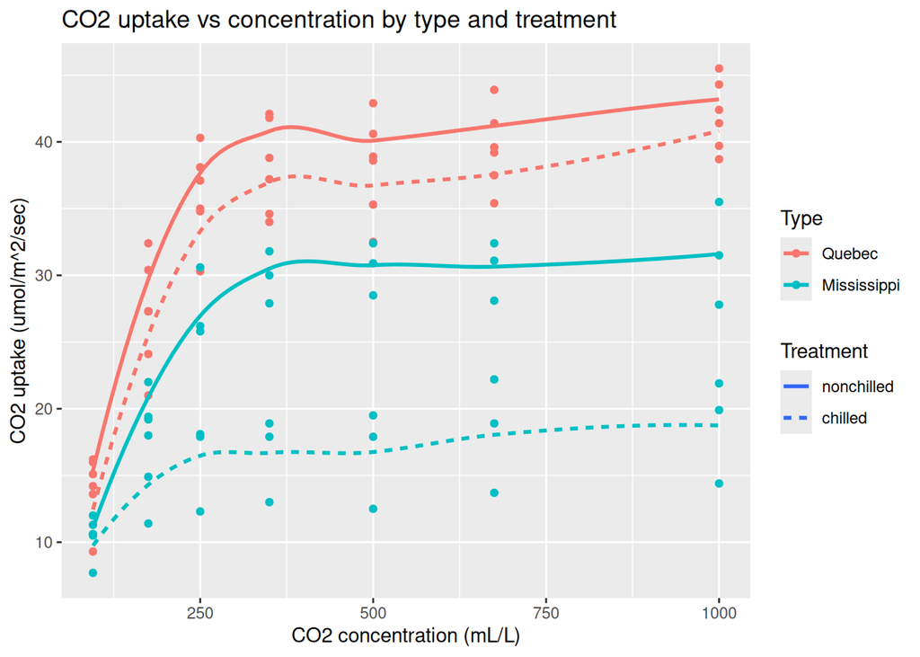

```r
ggplot(CO2, aes(x=conc, y=uptake, color=Type, linetype=Treatment)) +
  geom_point() +
  geom_smooth(se=FALSE) +
  labs(title="CO2 uptake vs concentration by type and treatment",
       x="CO2 concentration (mL/L)",
       y="CO2 uptake (umol/m^2/sec)")
```

Plotting uptake against concentration, split by both Type and Treatment, reveals several patterns not visible from summary statistics alone. Uptake increases with concentration but plateaus at higher levels, showing diminishing returns. Quebec plants consistently show higher uptake than Mississippi plants. Chilling reduces uptake more severely in Mississippi plants than Quebec plants suggesting that Quebec plants have greater cold tolerance.

## Task 8 - Tidybiology Package

### Installation and loading

```r
library(tidybiology)
library(tidyverse)
data(chromosome)
data(proteins)

head(chromosome)
```

```
## # A tibble: 6 × 14
##   id    length_mm basepairs variations protein_codinggenes pseudo_genes
##   <fct>     <dbl>     <dbl>      <dbl>               <int>        <int>
## 1 1            85 248956422   12151146                2058         1220
## 2 2            83 242193529   12945965                1309         1023
## 3 3            67 198295559   10638715                1078          763
## 4 4            65 190214555   10165685                 752          727
## 5 5            62 181538259    9519995                 876          721
## 6 6            58 170805979    9130476                1048          801
## # ℹ 8 more variables: totallongnc_rna <int>, totalsmallnc_rna <int>,
## #   mi_rna <int>, r_rna <int>, sn_rna <int>, sno_rna <int>, miscnc_rna <int>,
## #   centromereposition_mbp <dbl>
```

```r
head(proteins)
```

```
## # A tibble: 6 × 8
##   uniprot_id gene_name gene_name_alt   protein_name    protein_name_alt sequence
##   <chr>      <chr>     <chr>           <chr>           <chr>            <chr>
## 1 P04217     A1BG      <NA>            "Alpha-1B-glyc… Alpha-1-B glyco… MSMLVVF…
## 2 Q9NQ94     A1CF      ACF ASP         "APOBEC1 compl… APOBEC1-stimula… MESNHKS…
## 3 P01023     A2M       CPAMD5 FWP007   "Alpha-2-macro… Alpha-2-M) (C3 … MGKNKLL…
## 4 A8K2U0     A2ML1     CPAMD9          "Alpha-2-macro… C3 and PZP-like… MWAQLLL…
## 5 U3KPV4     A3GALT2   A3GALT2P IGBS3S "Alpha-1,3-gal… EC 2.4.1.87) (I… MALKEGL…
## 6 Q9NPC4     A4GALT    A14GALT A4GALT1 "Lactosylceram… EC 2.4.1.228) (… MSKPPDL…
## # ℹ 2 more variables: length <dbl>, mass <dbl>
```

The chromosome dataset contains 24 rows (one per chromosome) and 14 variables including chromosome length, number of variations, protein coding genes, and various RNA types. The proteins dataset contains ~20,000 human proteins with variables including sequence, length, and mass.

### 8a - Summary statistics for chromosome data

```r
summary_statistic <- chromosome %>%
  summarise(
    mean_variations = mean(variations),
    median_variations = median(variations),
    max_variations = max(variations),
    mean_proteincoding = mean(protein_codinggenes),
    median_proteincoding = median(protein_codinggenes),
    max_proteincoding = max(protein_codinggenes),
    mean_mirna = mean(mi_rna),
    median_mirna = median(mi_rna),
    max_mirna = max(mi_rna)
  )
print(summary_statistic)
```

```
## # A tibble: 1 × 9
##   mean_variations median_variations max_variations mean_proteincoding
##             <dbl>             <dbl>          <dbl>              <dbl>
## 1        6484572.           6172346       12945965               850.
## # ℹ 5 more variables: median_proteincoding <dbl>, max_proteincoding <int>,
## #   mean_mirna <dbl>, median_mirna <dbl>, max_mirna <int>
```

### 8b - Chromosome size distribution

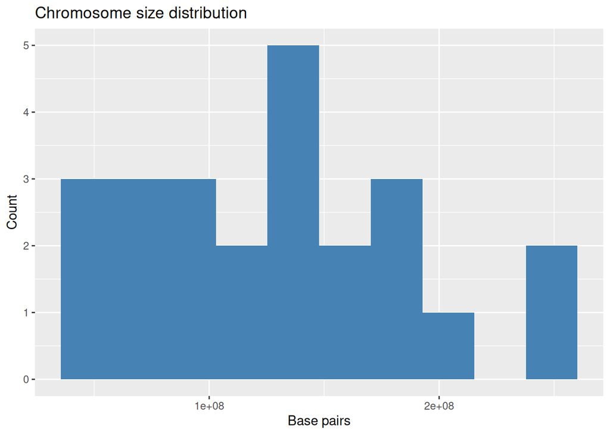

```r
ggplot(chromosome, aes(x=basepairs)) +
  geom_histogram(bins=10, fill="steelblue") +
  labs(title="Chromosome size distribution",
       x="Base pairs",
       y="Count")
```

### 8c - Protein coding genes and miRNA vs chromosome length

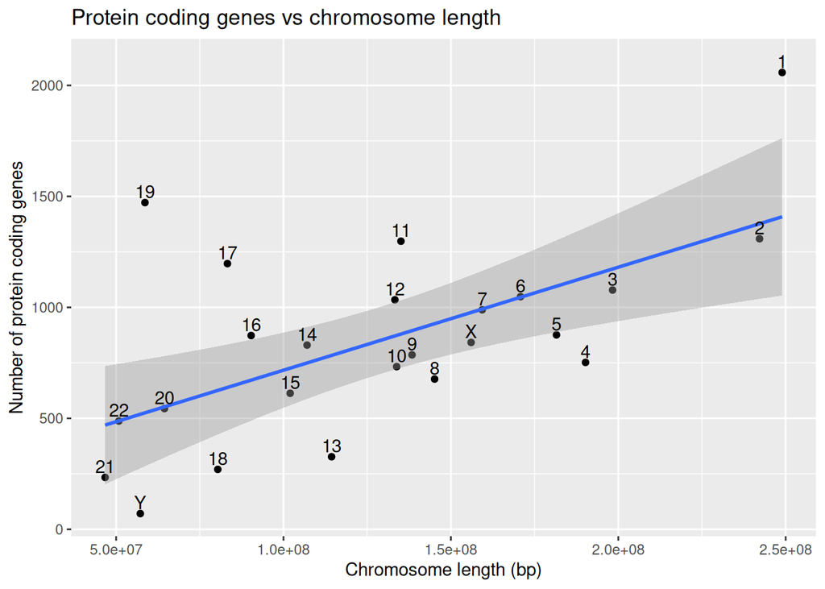

```r
ggplot(chromosome, aes(x=basepairs, y=protein_codinggenes, label=id)) +
  geom_point() +
  geom_smooth(method="lm") +
  geom_text(nudge_y=50) +
  labs(title="Protein coding genes vs chromosome length",
       x="Chromosome length (bp)",
       y="Number of protein coding genes")
```

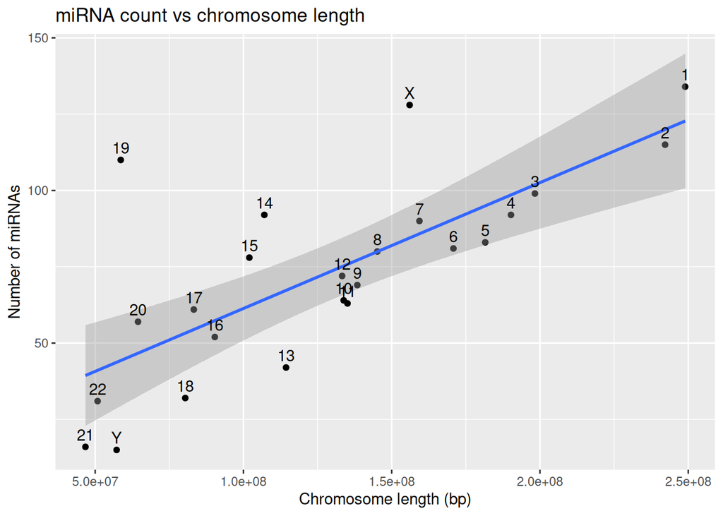

```r
ggplot(chromosome, aes(x=basepairs, y=mi_rna, label=id)) +
  geom_point() +
  geom_smooth(method="lm") +
  geom_text(nudge_y=4) +
  labs(title="miRNA count vs chromosome length",
       x="Chromosome length (bp)",
       y="Number of miRNAs")
```

Both protein coding genes and miRNA counts show a positive correlation with chromosome length — larger chromosomes tend to contain more genes and miRNAs.

### 8d - Protein length vs mass

```r
summary_statistic_2 <- proteins %>%
  summarise(
    mean_length = mean(length),
    median_length = median(length),
    max_length = max(length),
    mean_mass = mean(mass),
    median_mass = median(mass),
    max_mass = max(mass)
  )
print(summary_statistic_2)
```

```
## # A tibble: 1 × 6
##   mean_length median_length max_length mean_mass median_mass max_mass
##         <dbl>         <dbl>      <dbl>     <dbl>       <dbl>    <dbl>
## 1        557.           414      34350    62061.      46140.  3816030
```

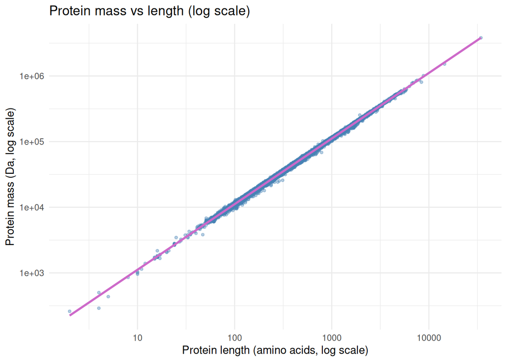

```r
ggplot(proteins, aes(x=length, y=mass)) +
  geom_point(alpha=0.4, color="steelblue", size=1) +
  geom_smooth(method="lm", color="orchid3") +
  scale_x_log10() +
  scale_y_log10() +
  theme_minimal() +
  labs(title="Protein mass vs length (log scale)",
       x="Protein length (amino acids, log scale)",
       y="Protein mass (Da, log scale)")
```

Protein mass and length show a near-perfect linear correlation on a log-log scale, consistent with the fact that protein mass is directly determined by amino acid composition and count. Log scaling was applied to both axes to reveal the distribution of the bulk of proteins, which are compressed into the bottom left of untransformed plot.